# Emisiones Gases En Corrales Lecheros

Emisiones Gases En Corrales Lecheros Jonatan Velez 2020-11-27

## Descripción de los datos

- **`Date`**: Fecha medición del flujo de gas.
- **`Barnyard`**: Corral (1 al 9).
- **`Surface`**: Material de la superficie del suelo del corral (Suelo, Arena, Corteza de árbol).
- **`Frame`**: Cuadro, las 2 ubicaciones de cámaras de muestreo aleatorio dentro de los corrales en cada día de muestreo (A, B, C y D).
- **`Sub_frame`**: Hora de medición en cada cuadro (M: Mañana, A: Tarde).
- **`Timing`**: Sincronización, medición antes o depués del día más cercano de encerrar las vacas en los corrales (Before: Antes, After: Después).
- **`Days_elapsed`**: Número de días desde que se sacaron las vacas del corral.
- **`Temp`**: Temperatura ambiente (Grados Celsius).
- **`CO2_mgC`**: Flujo dióxido de carbono (mg CO<sub>2</sub>-C/m<sup>2</sup>/hora).
- **`CH4_mgC`**: Flujo metano (mg CH<sub>4</sub>-C/m<sup>2</sup>/hora).
- **`NH3_ugN`**: Flujo amoniaco (ug NH<sub>3</sub>-N/m<sup>2</sup>/hora).
- **`N2O_ugN`**: Flujo óxido nitroso (ug N<sub>2</sub>O-N/m<sup>2</sup>/hora).
- **`CO2_mg`**: Flujo dióxido de carbono (mg CO<sub>2</sub>/m<sup>2</sup>/hora).
- **`CH4_mg`**: Flujo metano (mg CH<sub>4</sub>/m<sup>2</sup>/hora).
- **`NH3_mg`**: Flujo amoniaco (mg NH<sub>3</sub>/m<sup>2</sup>/hora).
- **`N2O_mg`**: Flujo óxido nitroso (mg N<sub>2</sub>O/m<sup>2</sup>/hora).
- **`CO2_eq`**: Equivalentes GEI (mg CO<sub>2</sub>-eq/m<sup>2</sup>/hora).

#### Librerías requeridas

```r
library(readxl) # Lectura datos
library(tidyverse) # dplyr, ggplot2
library(corrplot) # Correlaciones
library(corrr) # Gráfico correlaciones
```

#### Lectura de datos

```r
Emisiones_Gases <- read_xlsx("BYD_Project_Data.xlsx",
                             sheet = "GHG") %>%
    data.frame()
```

#### Estructura de los datos

```r
str(Emisiones_Gases)
```

```
## 'data.frame':    3237 obs. of  17 variables:
##  $ Date        : POSIXct, format: "2011-05-17" "2011-05-17" ...
##  $ Barnyard    : num  1 1 2 2 3 3 4 4 5 5 ...
##  $ Surface     : chr  "SOIL" "SOIL" "SOIL" "SOIL" ...
##  $ Frame       : chr  "A" "B" "A" "B" ...
##  $ Sub_frame   : chr  "M" "M" "M" "M" ...
##  $ Timing      : chr  "BEFORE" "BEFORE" "BEFORE" "BEFORE" ...
##  $ Days_elapsed: num  205 205 205 205 205 205 205 205 205 205 ...
##  $ Temp        : num  15.3 16.2 16.4 16.5 18.7 ...
##  $ CO2_mgC     : chr  "183" "260" "316" "305" ...
##  $ CH4_mgC     : chr  "0.69899999999999995" "1.25" "3.48" "3.42" ...
##  $ NH3_ugN     : chr  "140" "46.8" "196" "425" ...
##  $ N2O_ugN     : chr  "2730" "1800" "3960" "6390" ...
##  $ CO2_mg      : chr  "670" "952" "1160" "1120" ...
##  $ CH4_mg      : chr  "0.93200000000000005" "1.66" "4.6399999999999997" "4.57" ...
##  $ NH3_mg      : chr  "0.17" "5.6800000000000003E-2" "0.23799999999999999" "0.51700000000000002" ...
##  $ N2O_mg      : chr  "4.29" "2.82" "6.23" "10" ...
##  $ CO2_eq      : chr  "1970" "1830" "3130" "4230" ...
```

## Gráficos de dispersión

### Relación entre GEI y el flujo de metano

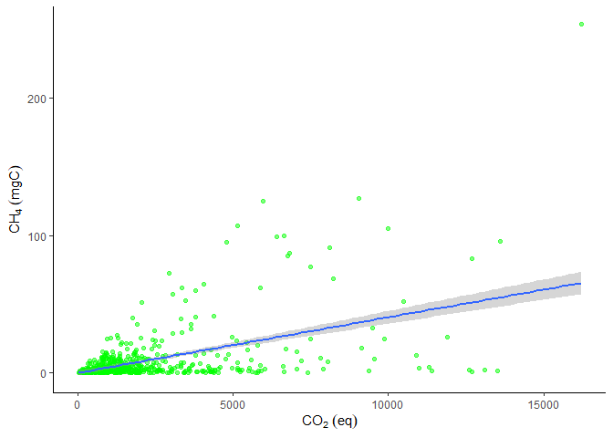

```r
ggplot(Emisiones_Gases, aes(as.numeric(CO2_eq),
                            as.numeric(CH4_mgC),
                            rm.na = TRUE)) +
    geom_point(color = "green", alpha = 0.5) +
    geom_smooth(method = "lm") +
    labs(x = expression(CO[2]~ (eq)),
         y = expression(CH[4]~ (mgC))) +
    theme_classic()
```

### Relación entre GEI y el flujo de óxido nitroso

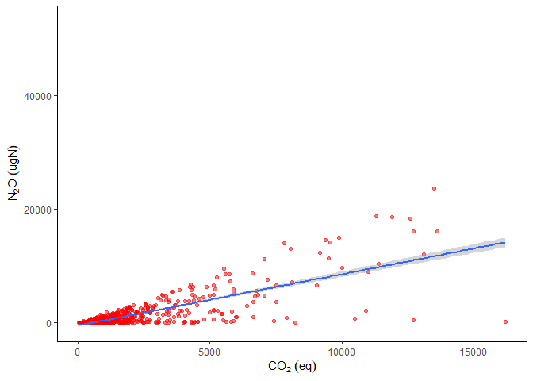

```r
ggplot(Emisiones_Gases, aes(as.numeric(CO2_eq),
                            as.numeric(N2O_ugN),
                            rm.na = TRUE)) +
    geom_point(color = "red", alpha = 0.5) +
    geom_smooth(method = "lm") +
    labs(x = expression(CO[2]~ (eq)),
         y = expression(paste(N[2],O~ (ugN)))) +
    theme_classic()
```

### Relación temperatura y flujo de metano

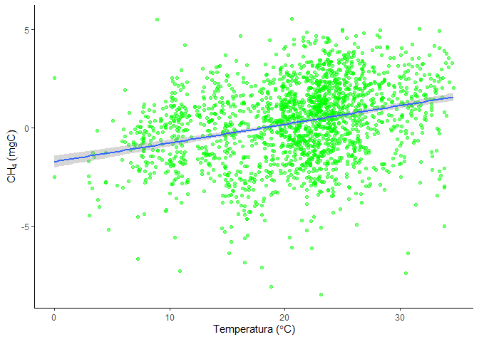

```r
ggplot(Emisiones_Gases, aes(as.numeric(Temp),
                            log(as.numeric(CH4_mgC)),
                            rm.na = TRUE)) +
    geom_point(color = "green", alpha = 0.5) +
    geom_smooth(method = "lm") +
    labs(x = expression('Temperatura ('*degree*C*')'),
         y = expression(CH[4]~ (mgC))) +
    theme_classic()
```

### Relación temperatura y emisiones GEI

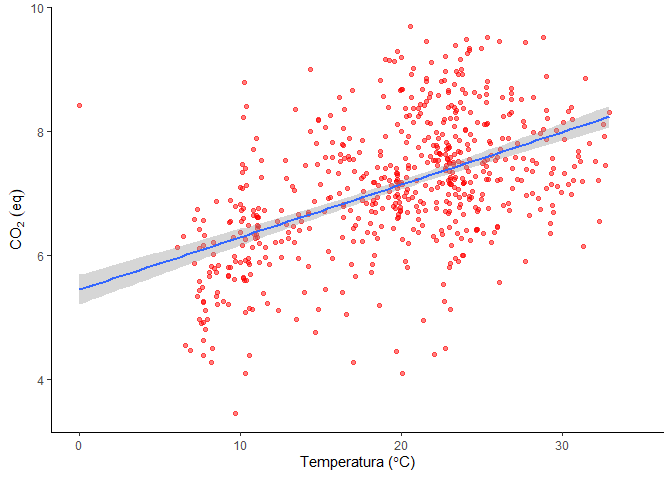

```r
ggplot(Emisiones_Gases, aes(as.numeric(Temp),
                            log(as.numeric(CO2_eq)),
                            rm.na = TRUE)) +
    geom_point(color = "red", alpha = 0.5) +
    geom_smooth(method = "lm") +
    labs(x = expression('Temperatura ('*degree*C*')'),
         y = expression(CO[2]~ (eq))) +
    theme_classic()
```

## Diagrama de caja (Box plot)

### Emisiones GEI según el tipo de suelo del corral

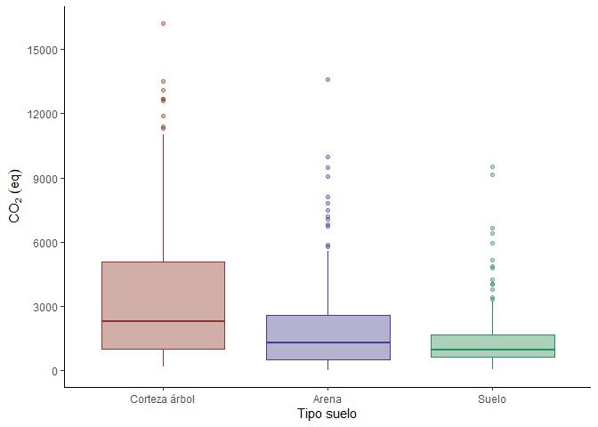

```r
ggplot(Emisiones_Gases, aes(as.factor(Surface),
                            as.numeric(CO2_eq))) +
    geom_boxplot(color = c("tomato4", "slateblue4", "seagreen4"),
                 fill = c("tomato4", "slateblue4", "seagreen4"),
                 alpha = 0.4) +
    scale_y_continuous(breaks = seq(from = 0, to = 17000,
                                    by = 3000)) +
    scale_x_discrete(labels = c("Corteza árbol",
                                "Arena", "Suelo"),
                     na.translate = FALSE) +
    labs(x = "Tipo suelo",
         y = expression(CO[2]~ (eq))) +
    theme_classic()
```

### Emisiones GEI según la hora de medición

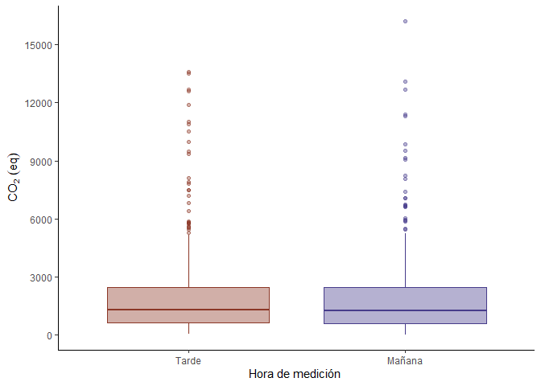

```r
ggplot(Emisiones_Gases, aes(as.factor(Sub_frame),
                            as.numeric(CO2_eq))) +
    geom_boxplot(color = c("tomato4", "slateblue4"),
                 fill = c("tomato4", "slateblue4"),
                 alpha = 0.4) +
    scale_y_continuous(breaks = seq(from = 0, to = 17000,
                                    by = 3000)) +
    scale_x_discrete(labels = c("Tarde", "Mañana"),
                     na.translate = FALSE) +
    labs(x = "Hora de medición ",
         y = expression(CO[2]~ (eq))) +
    theme_classic()
```

## Correlaciones variables cuantitativas

### Matriz de correlaciones

```r
Emisiones_Gases2 <- as.data.frame(sapply(Emisiones_Gases,
                                        as.numeric)) %>%
    select(8:17) %>%
    cor(use = "pairwise.complete.obs")
Emisiones_Gases2
```

```
##               Temp    CO2_mgC    CH4_mgC      NH3_ugN      N2O_ugN     CO2_mg
## Temp    1.00000000 0.27986391 0.16895015 0.0132162176 0.1639834546 0.27985509
## CO2_mgC 0.27986391 1.00000000 0.11637021 0.0551497649 0.1465937418 0.99999695
## CH4_mgC 0.16895015 0.11637021 1.00000000 0.0213791632 0.0838613434 0.11639418
## NH3_ugN 0.01321622 0.05514976 0.02137916 1.0000000000 0.0008690136 0.05522145
## N2O_ugN 0.16398345 0.14659374 0.08386134 0.0008690136 1.0000000000 0.14659911
## CO2_mg  0.27985509 0.99999695 0.11639418 0.0552214486 0.1465991120 1.00000000
## CH4_mg  0.16906185 0.11641283 0.99999716 0.0213514267 0.0839315082 0.11643690
## NH3_mg  0.01323300 0.05517842 0.02142161 0.9999988741 0.0008609989 0.05525030
## N2O_mg  0.16396517 0.14649051 0.08390366 0.0008412858 0.9999974367 0.14649576
## CO2_eq  0.31736656 0.79783588 0.50004266 0.0118842356 0.7700373169 0.79782724
##             CH4_mg       NH3_mg       N2O_mg     CO2_eq
## Temp    0.16906185 0.0132330016 0.1639651674 0.31736656
## CO2_mgC 0.11641283 0.0551784204 0.1464905072 0.79783588
## CH4_mgC 0.99999716 0.0214216107 0.0839036607 0.50004266
## NH3_ugN 0.02135143 0.9999988741 0.0008412858 0.01188424
## N2O_ugN 0.08393151 0.0008609989 0.9999974367 0.77003732
## CO2_mg  0.11643690 0.0552503047 0.1464957639 0.79782724
## CH4_mg  1.00000000 0.0213938586 0.0839738681 0.50019963
## NH3_mg  0.02139386 1.0000000000 0.0008332029 0.01190146
## N2O_mg  0.08397387 0.0008332029 1.0000000000 0.77007592
## CO2_eq  0.50019963 0.0119014626 0.7700759195 1.00000000
```

### Gráficos correlaciones

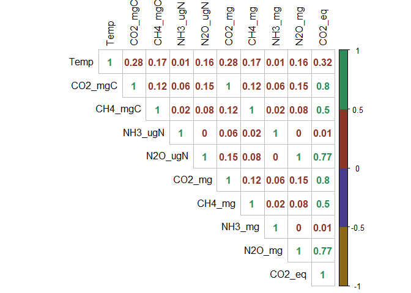

```r
corrplot(Emisiones_Gases2 ,
         method = "number",
         tl.col = "black",
         type = "upper",
         col = c("goldenrod4","slateblue4",
                  "tomato4", "seagreen4"))
```

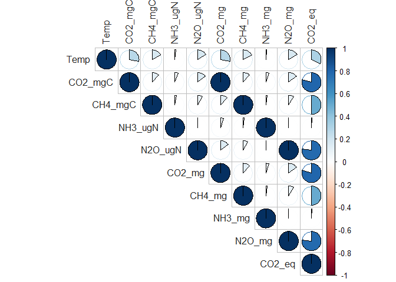

```r
corrplot(Emisiones_Gases2,
         method = "pie",
         type = "upper",
         tl.col = "gray14")
```

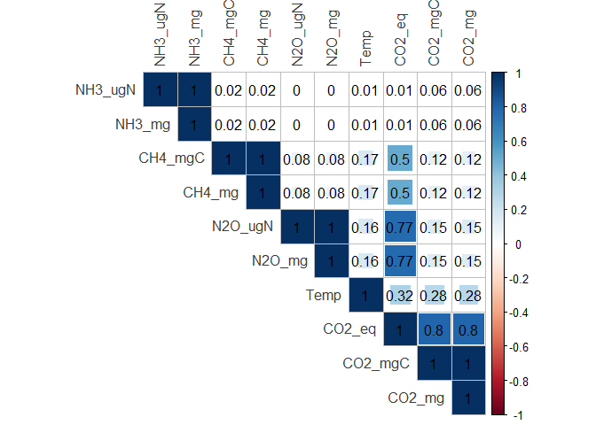

```r
corrplot(Emisiones_Gases2,
         p.mat = Emisiones_Gases2,
         method = "square",
         type = "upper",
         order = "hclust",
         addrect = 2,
         tl.col = "gray24",
         pch.col = "Black",
         insig = "p-value",
         sig.level = -1)
```

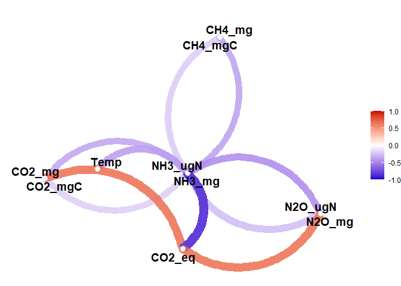

```r
Emisiones_Gases2 %>%
    correlate() %>%
    network_plot(colors = c("blue3", "white", "red3"))
```